# 打零工比上班族好賺？

Andrew Tang

2017年5月1日

## 套件載入

```r
library(readr)
library(stringr)
library(magrittr)
library(DT)
```

## 資料集

- 資料集描述：有關我國基本工資制定與調整之歷史沿革
- 主要欄位說明：序號、指示/發布日期、內容/調整金額、實施日期
- 資料集提供機關名稱：勞動部
- 資料量：約26筆

## 資料載入

- 因為欄位名稱許多符號，簡化之

```r
dataset <- read_csv("http://data.gov.tw/iisi/logaccess/70163?dataUrl=http://apiservice.mol.gov.tw/OdService/download/A17000000J-020050-MUA&ndctype=CSV&ndcnid=6281")
names(dataset) <- c("annc_date", "salary", "started")
```

## 資料處理

- 目測前六筆資料無用

```r
dataset <- dataset[-c(1:6),]
```

|  | annc_date | salary | started |
| --- | --- | --- | --- |
| 1 | 67年11月29日 | 月薪2,400、日薪80 | 67年12月1日 |
| 2 | 69年4月29日 | 月薪3,300、日薪110 | 69年5月1日 |
| 3 | 72年4月29日 | 月薪5,700、日薪190 | 72年5月1日 |
| 4 | 73年6月14日 | 月薪6,150、日薪205 | 73年7月1日 |
| 5 | 75年10月27日 | 月薪6,900、日薪230 | 75年11月1日 |
| 6 | 77年6月28日 | 月薪8,130、日薪271 | 77年7月1日 |
| 7 | 78年6月26日 | 月薪8,820、日薪294 | 78年7月1日 |
| 8 | 79年7月25日 | 月薪9,750、日薪325 | 79年8月1日 |
| 9 | 80年8月1日 | 月薪11,040、日薪368 | 80年8月1日 |
| 10 | 81年8月13日 | 月薪12,365、日薪412、時薪51.5 | 81年8月1日 |

[output cut: 15 more lines]

- 將文字中的月薪、日薪及時薪分別取出

```r
dataset$monthly <- str_extract_all(dataset$salary, "月薪.*", simplify = T) %>%
  strsplit("、") %>% sapply(`[`, 1) %>% gsub("月薪|,","", .) %>% as.numeric()

dataset$daily <- str_extract_all(dataset$salary, "日薪.*", simplify = T) %>%
  strsplit("、") %>% sapply(`[`, 1) %>% gsub("日薪|,","", .) %>% as.numeric()

dataset$hourly <- str_extract_all(dataset$salary, "時薪.*", simplify = T) %>%
  strsplit("、") %>% sapply(`[`, 1) %>% gsub("時薪|,","", .) %>% as.numeric()
```

- 目測補值：
  - 102年4月1日生效的調整月薪可以合併至102年1月1日
  - 103年7月1日生效的調整月薪可以合併至103年1月1日
  - 106年1月1日生效的調整時薪讓105年10月1日生效的調整時薪顯得無意義

```r
dataset$monthly[dataset$started=="102年1月1日"] <- dataset$monthly[dataset$started=="102年4月1日"]
dataset$monthly[dataset$started=="103年1月1日"] <- dataset$monthly[dataset$started=="103年7月1日"]

dataset <- dataset[(dataset$started!="102年4月1日" &
                    dataset$started!="103年7月1日" &
                    dataset$started!="105年10月1日"),]
```

## 資料轉換

- 將時薪(1日工作8小時)轉換為日薪

```r
dataset$daily[is.na(dataset$daily)] <- dataset$hourly[is.na(dataset$daily)] * 8
```

## 結果呈現與視覺化

- 以日薪與月薪的比例，思考打零工與上班族的差距
- 從民國67年至86年，月薪相等於每月工作30日，每日工作8小時

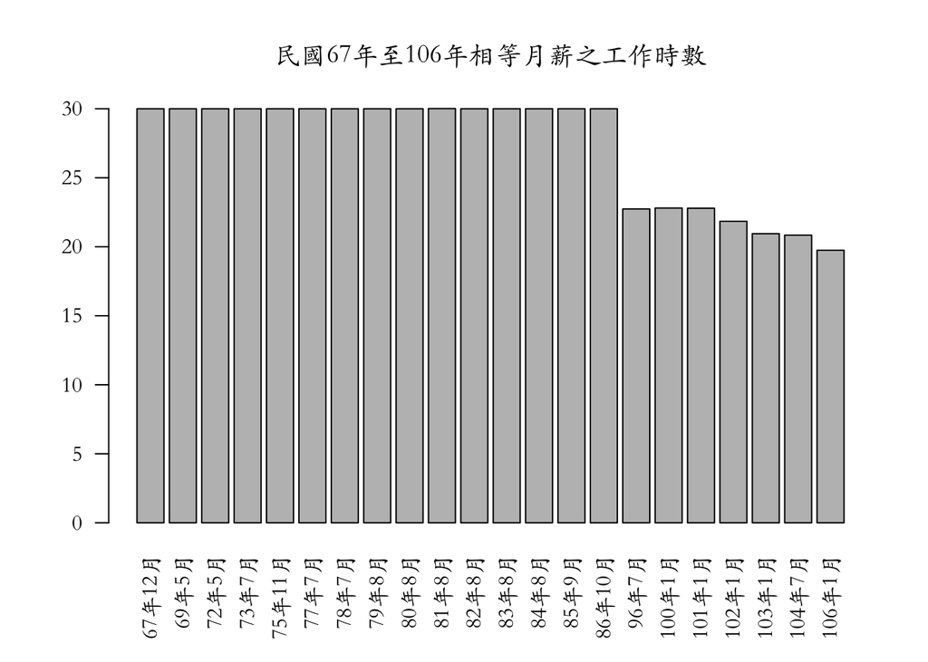

```r
tmp <- dataset$monthly/dataset$daily
tmp <- as.table(tmp)
names(tmp) <- str_extract_all(dataset$started,".*月",simplify = T)
par(family = "STKaiti")
barplot(tmp, las=2, main = "民國67年至106年相等月薪之工作時數")
```

- 將民國67年至86年的資料忽略試試
- 由圖表可知：
  - 96年至101年，時薪制員工每日工作8小時並工作約23日，薪水與月薪制相同
  - 102年起至今年，同樣工作8小時，工作天數逐年下降至約工作20日，可與月薪制相同

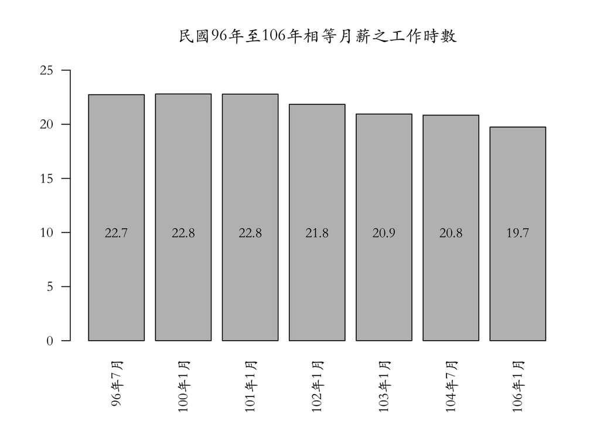

```r
par(family = "STKaiti")
bp <- barplot(tmp[-c(1:15)], las=2, main = "民國96年至106年相等月薪之工作時數",
        ylim = c(0,25))
text(bp,y=10,labels = round(tmp[-c(1:15)],1))
```